# Unsupervised Learning: Trade&Ahead

```python
df.groupby("GICS Sector")["Earnings Per Share"].mean().sort_values(ascending=False)
```

```
GICS Sector
Health Care                    4.54
Consumer Discretionary         4.53
Industrials                    4.46
Financials                     4.22
Telecommunications Services    3.55
Consumer Staples               3.22
Materials                      3.13
Utilities                      2.75
Real Estate                    2.34
Information Technology         2.27
Energy                        -6.91
Name: Earnings Per Share, dtype: float64
```

- Health care, Consumer Discretionary, and Industrials have the highest Earnings per share amongst trhe listed securities. The Energy sector have a negative Earnings per share which is an indication that the business is not profitable.

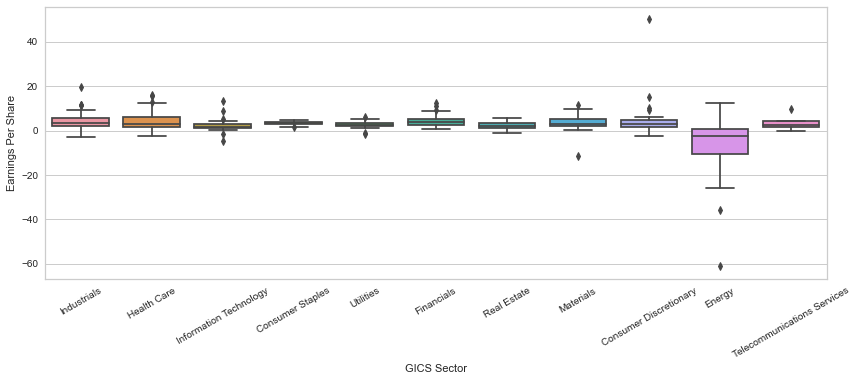

```python
plt.figure(figsize=(14, 5))
sns.boxplot(data=df, y="Earnings Per Share", x="GICS Sector")
plt.xticks(rotation=30)
plt.show()
```

- The Energy Sector has a large negative Earnings per share with negative outliers

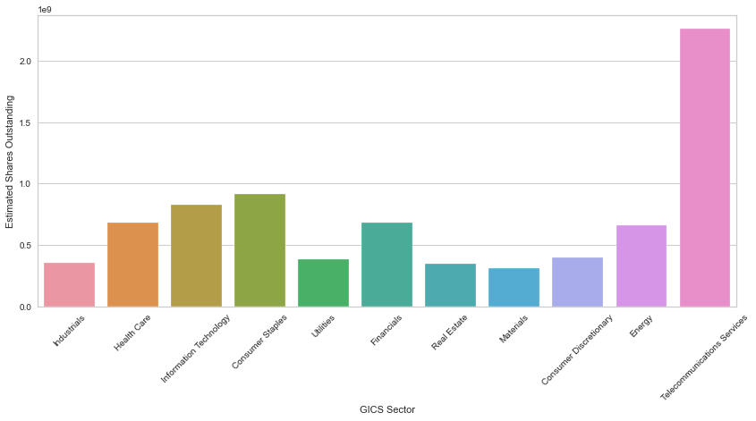

```python
plt.figure(figsize=(14, 6))
sns.barplot(
    data=df, y="Estimated Shares Outstanding", x="GICS Sector", ci=False
)  ## Complete the code to choose the right variables
plt.xticks(rotation=45)
plt.show()
```

- Telecommunication services have the highest Estimated Shares outstanding, whereas the Materials and Real estate sector have the lowest.

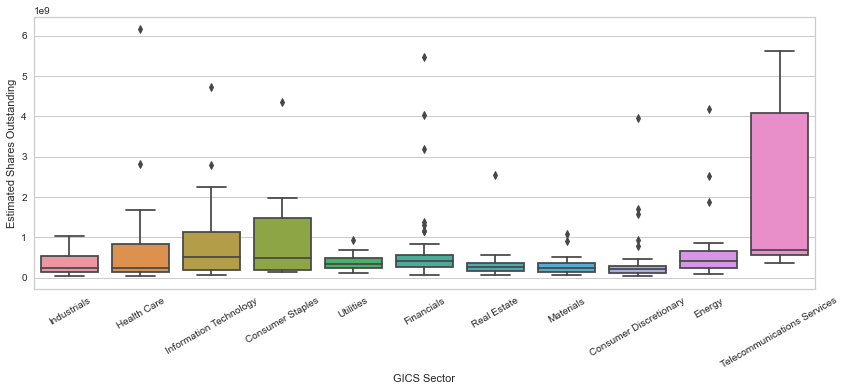

```python
plt.figure(figsize=(14, 5))
sns.boxplot(data=df, y="Estimated Shares Outstanding", x="GICS Sector")
plt.xticks(rotation=30)
plt.show()
```

- Telecommunication Services has the biggest Estimated Shares outstanding swing, followed by Consumer Staples and Information technology. An indication of how active these equities are on the exchange floor.

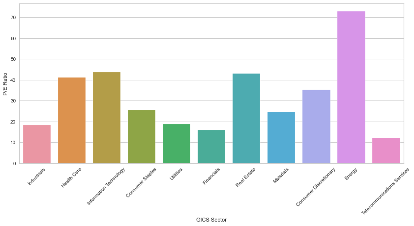

```python
plt.figure(figsize=(14, 6))
sns.barplot(
    data=df, y="P/E Ratio", x="GICS Sector", ci=False
)  ## Complete the code to choose the right variables
plt.xticks(rotation=45)
plt.show()
```

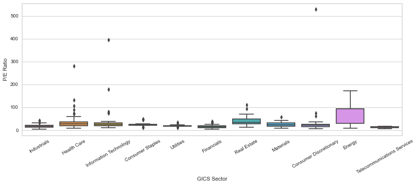

```python
plt.figure(figsize=(14, 5))
sns.boxplot(data=df, y="P/E Ratio", x="GICS Sector")
plt.xticks(rotation=30)
plt.show()
```

```python
df.groupby("GICS Sector")["P/E Ratio"].mean().sort_values(ascending=False)
```

```
GICS Sector
Energy                        72.90
Information Technology        43.78
Real Estate                   43.07
Health Care                   41.14
Consumer Discretionary        35.21
Consumer Staples              25.52
Materials                     24.59
Utilities                     18.72
Industrials                   18.26
Financials                    16.02
Telecommunications Services   12.22
Name: P/E Ratio, dtype: float64
```

### Question 5

**P/E ratios can help determine the relative value of a company's shares as they signify the amount of money an investor is willing to invest in a single share of a company per dollar of its earnings. How does the P/E ratio vary, on average, across economic sectors?**

- The Energy sector has the highest average P/E ratios of all sectors followed by the Information Technology and the Real Estate sectors. The Telecommunication services sector followed by the Financials and Insdustrials have the lowest P/E ratio on the average among the listed securities

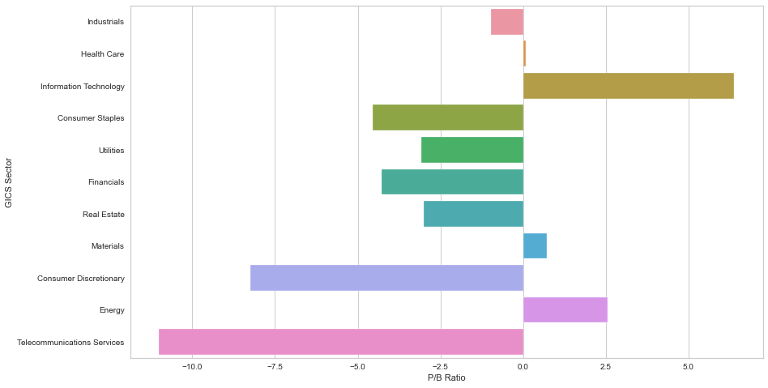

```python
plt.figure(figsize=(14, 8))
sns.barplot(
    data=df, x="P/B Ratio", y="GICS Sector", ci=False
)  ## Complete the code to choose the right variables
plt.show()
```

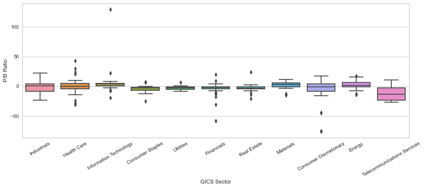

```python
plt.figure(figsize=(14, 5))
sns.boxplot(data=df, y="P/B Ratio", x="GICS Sector")
plt.xticks(rotation=30)
plt.show()
```

- Telecommunication services have the laegest price per Boo ratio (P/B ratio) swing amongst the listed equities followed by equities in the Industrial sector.

## Data Preprocessing

- Duplicate value check
- Missing value treatment
- Outlier check
- Feature engineering (if needed)
- Any other preprocessing steps (if needed)

### Duplicate and Missing value Check

- There are no duplicate values in the dataset. Neither are there missing values.

### Outlier Check

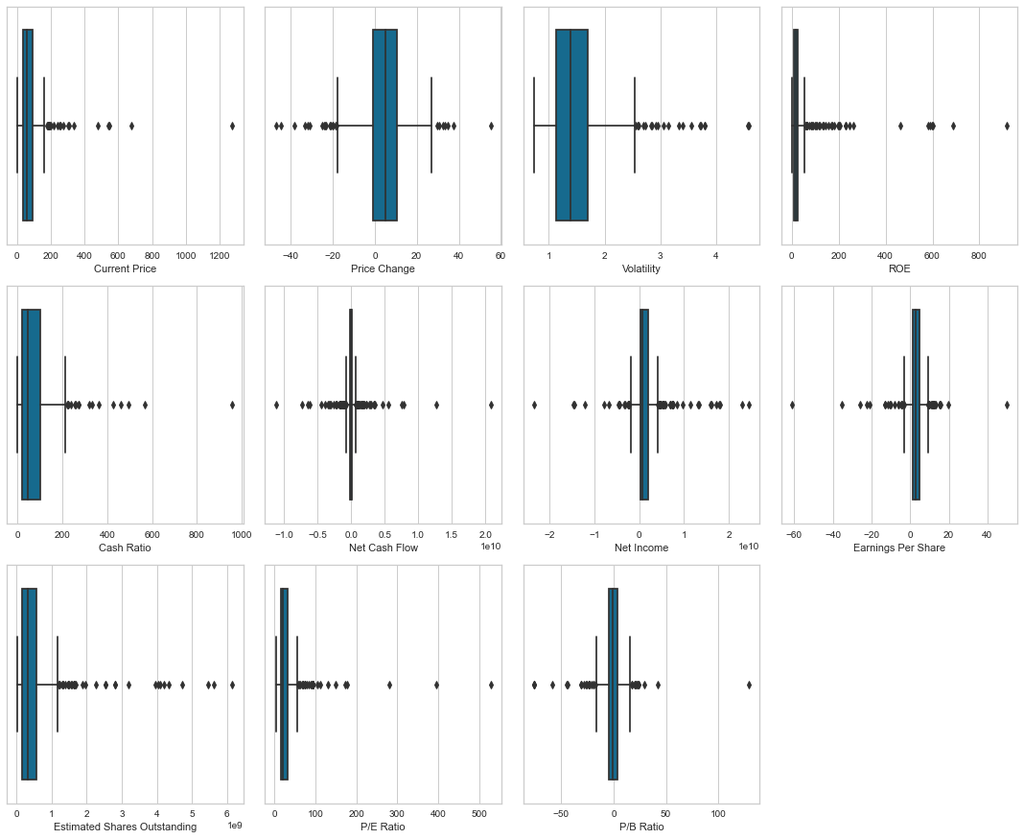

```python
plt.figure(figsize=(15, 20))

for j, column in enumerate(num_columns):
    plt.subplot(5, 4, j + 1)
    sns.boxplot(data=df, x=column)
    plt.tight_layout()
plt.show()
```

### Scaling the data

```python
# Scaling the dataset in preparation for clustering
scaler = StandardScaler()
df_subset = df[num_columns].copy()
df_subset_scaled = pd.DataFrame(
    scaler.fit_transform(df_subset), columns=df_subset.columns
)
```

```python
# Unscaled subset of the original dataset with the categorical variables dropped
df_subset.head()
```

|  | Current Price | Price Change | Volatility | ROE | Cash Ratio | Net Cash Flow | Net Income | Earnings Per Share | Estimated Shares Outstanding | P/E Ratio | P/B Ratio |
| --- | --- | --- | --- | --- | --- | --- | --- | --- | --- | --- | --- |
| 0 | 42.35 | 10.00 | 1.69 | 135 | 51 | -604000000 | 7610000000 | 11.39 | 668,129,938.50 | 3.72 | -8.78 |
| 1 | 59.24 | 8.34 | 2.20 | 130 | 77 | 51000000 | 5144000000 | 3.15 | 1,633,015,873.00 | 18.81 | -8.75 |
| 2 | 44.91 | 11.30 | 1.27 | 21 | 67 | 938000000 | 4423000000 | 2.94 | 1,504,421,769.00 | 15.28 | -0.39 |
| 3 | 93.94 | 13.98 | 1.36 | 9 | 180 | -240840000 | 629551000 | 1.26 | 499,643,650.80 | 74.56 | 4.20 |
| 4 | 55.32 | -1.83 | 1.70 | 14 | 272 | 315120000 | 696878000 | 0.31 | 2,247,993,548.00 | 178.45 | 1.06 |

```python
# Scaled subset of the original dataset
df_subset_scaled.head()
```

|  | Current Price | Price Change | Volatility | ROE | Cash Ratio | Net Cash Flow | Net Income | Earnings Per Share | Estimated Shares Outstanding | P/E Ratio | P/B Ratio |
| --- | --- | --- | --- | --- | --- | --- | --- | --- | --- | --- | --- |
| 0 | -0.39 | 0.49 | 0.27 | 0.99 | -0.21 | -0.34 | 1.55 | 1.31 | 0.11 | -0.65 | -0.51 |
| 1 | -0.22 | 0.36 | 1.14 | 0.94 | 0.08 | -0.00 | 0.93 | 0.06 | 1.25 | -0.31 | -0.50 |
| 2 | -0.37 | 0.60 | -0.43 | -0.19 | -0.03 | 0.45 | 0.74 | 0.02 | 1.10 | -0.39 | 0.09 |
| 3 | 0.13 | 0.83 | -0.28 | -0.32 | 1.22 | -0.15 | -0.22 | -0.23 | -0.09 | 0.95 | 0.42 |
| 4 | -0.26 | -0.49 | 0.30 | -0.27 | 2.24 | 0.13 | -0.20 | -0.37 | 1.98 | 3.29 | 0.20 |

### EDA

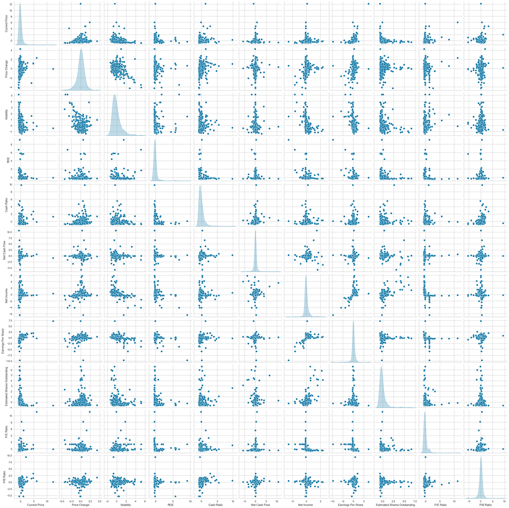

```python
# Plotting a pairplot of the scaled variables
sns.pairplot(df_subset_scaled, diag_kind="kde")
```

- All attributes of the dataset have now been scaled with the mean and standard deviation of each of the features being 0 and 1 respectively.
- The relationship between the attributes are still maintained after the scaling. There were outliers detected in the dataset, but we chose not to treat them because we believe that they are real data points.

## K-means Clustering

```
Number of Clusters: 1 	Average Distortion: 2.5425069919221697
Number of Clusters: 2 	Average Distortion: 2.384499097487295
Number of Clusters: 3 	Average Distortion: 2.2692367155390745
Number of Clusters: 4 	Average Distortion: 2.175554082632614
Number of Clusters: 5 	Average Distortion: 2.1314038328119898
Number of Clusters: 6 	Average Distortion: 2.061150683463396
Number of Clusters: 7 	Average Distortion: 2.0336527899234786
Number of Clusters: 8 	Average Distortion: 1.970145565803588
Number of Clusters: 9 	Average Distortion: 1.933332845036278
Number of Clusters: 10 	Average Distortion: 1.8768270176193675
```

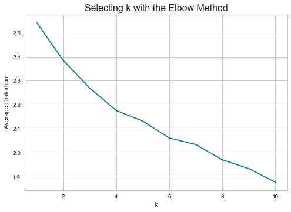

```python
# Checking the average distortion for a range of 10 kmeans models fitted to the scaled dataset
clusters = range(1, 11)
meanDistortions = []

for k in clusters:
    model = KMeans(n_clusters=k, random_state=10)
    model.fit(df_subset_scaled)
    prediction = model.predict(df_subset_scaled)
    distortion = (
        sum(
            np.min(cdist(df_subset_scaled, model.cluster_centers_, "euclidean"), axis=1)
        )
        / df_subset_scaled.shape[0]
    )

    meanDistortions.append(distortion)

    print("Number of Clusters:", k, "\tAverage Distortion:", distortion)

plt.plot(clusters, meanDistortions, "bx-")
plt.xlabel("k")
plt.ylabel("Average Distortion")
plt.title("Selecting k with the Elbow Method", fontsize=16)
```

**From the Elbow plot above, we can choose a k value between 4 and 6**

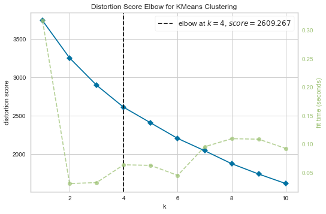

```python
# Using the KElbow visualizaer to find the optimal K value using the default metric (distortion)
model = KMeans(random_state=10)
visualizer = KElbowVisualizer(model, k=(1, 11), timings=True)
visualizer.fit(df_subset_scaled)
visualizer.show()
```

**The KElbow visualizer indicates an optimal k value of 4**

```
For n_clusters = 2, silhouette score is 0.4484662124740991
For n_clusters = 3, silhouette score is 0.4644405674779404
For n_clusters = 4, silhouette score is 0.45434371948348606
For n_clusters = 5, silhouette score is 0.4521418829415027
For n_clusters = 6, silhouette score is 0.35953816980755665
For n_clusters = 7, silhouette score is 0.38589076005669404
For n_clusters = 8, silhouette score is 0.4136907027942303
For n_clusters = 9, silhouette score is 0.43469939265862173
For n_clusters = 10, silhouette score is 0.24297361650978766
```

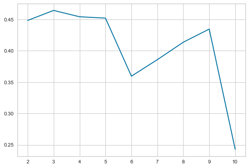

```python
# Calculating the silhouette scores for a range of 2 to 10 clusters
sil_score = []
cluster_list = list(range(2, 11))
for n_clusters in cluster_list:
    clusterer = KMeans(n_clusters=n_clusters, random_state=10)
    preds = clusterer.fit_predict((df_subset_scaled))
    score = silhouette_score(df_subset_scaled, preds)
    sil_score.append(score)
    print("For n_clusters = {}, silhouette score is {}".format(n_clusters, score))

plt.plot(cluster_list, sil_score)
plt.show()
```

**A k value of 3, 4, or 5 can be justified with the silhouette plot**

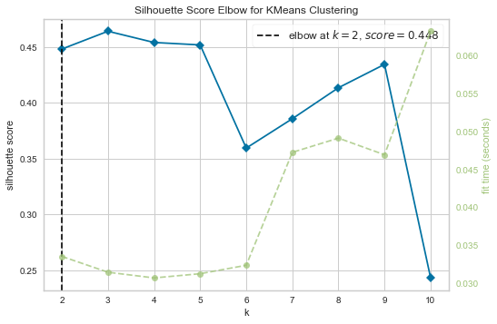

```python
# Using the KElbow visualizaer to find the optimal K value using silhoutte score as the metric
model = KMeans(random_state=10)
visualizer = KElbowVisualizer(model, k=(2, 11), metric="silhouette", timings=True)
visualizer.fit(df_subset_scaled)
visualizer.show()
```

**The Silhouette score Elbow plot indicates a k value of 2, but from visual observation, we'll rather go with k values ranging from 3 to 5**

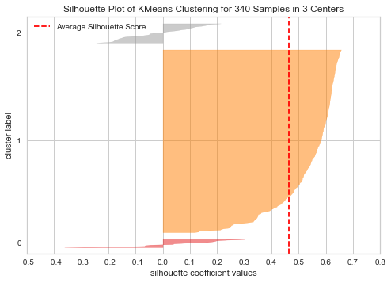

```python
visualizer = SilhouetteVisualizer(KMeans(3, random_state=10))
visualizer.fit(df_subset_scaled)
visualizer.show()
```

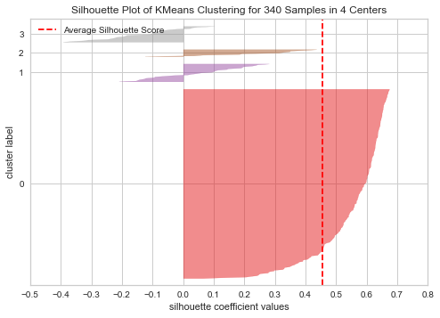

```python
visualizer = SilhouetteVisualizer(KMeans(4, random_state=10))
visualizer.fit(df_subset_scaled)
visualizer.show()
```

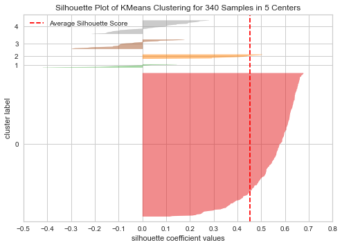

```python
visualizer = SilhouetteVisualizer(KMeans(5, random_state=10))
visualizer.fit(df_subset_scaled)
visualizer.show()
```

#### Observation

- Based on the KElbow visualizer with distortion as the default metric and our visual observation of the Silhouette score elbow plot and Silhouette visualizers for k values of 3, 4 and 5, we will go with a k value of 4.

```python
# Choosing 4 as the number of clusters and fitting the model to the scaled dataset
kmeans = KMeans(n_clusters=4, random_state=10)

# fit model to scaled dataset
kmeans.fit(df_subset_scaled)
```

```
KMeans(n_clusters=4, random_state=10)
```

```python
# Creating a copy of the original dataset to be used for cluster profiling
df_kmeans = df.copy()
```

### Cluster Profiling

```python
# Adding kmeans cluster labels to the copy of the original dataset
df_kmeans["km_cluster_no"] = kmeans.labels_
```

```python
# Adding kmeans cluster labels to the scaled dataset (for plotting the final boxplots)
df_km_scaled = df_subset_scaled.copy()
df_km_scaled["km_cluster_no"] = kmeans.labels_
```

```python
# Group dataset by kmeans cluster labels
cluster_profile = df_kmeans.groupby("km_cluster_no").mean()
```

```python
# add counts for number of stocks in each cluster
cluster_profile["Count"] = (
    df_kmeans.groupby("km_cluster_no")["Current Price"].count().values
)
```

```python
# Displaying the cluster profiles
cluster_profile.style.highlight_max(color="lime", axis=0).highlight_min(
    color="yellow", axis=0
).highlight_between(left=-9000000000, right=0, color="deeppink", axis=0)
```

| km_cluster_no | Current Price | Price Change | Volatility | ROE | Cash Ratio | Net Cash Flow | Net Income | Earnings Per Share | Estimated Shares Outstanding | P/E Ratio | P/B Ratio | Count |
| --- | --- | --- | --- | --- | --- | --- | --- | --- | --- | --- | --- | --- |
| 0 | 72.199223 | 5.078363 | 1.388428 | 34.517986 | 53.165468 | 60694949.640288 | 1534031769.784173 | 3.623040 | 439996194.215863 | 23.804667 | -3.350239 | 278 |
| 1 | 38.099260 | -15.370329 | 2.910500 | 107.074074 | 50.037037 | -159428481.481481 | -3887457740.740741 | -9.473704 | 480398572.845926 | 90.619220 | 1.342067 | 27 |
| 2 | 50.517273 | 5.747586 | 1.130399 | 31.090909 | 75.909091 | -1072272727.272727 | 14833090909.090910 | 4.154545 | 4298826628.727273 | 14.803577 | -4.552119 | 11 |
| 3 | 243.226804 | 13.607350 | 1.742959 | 26.416667 | 285.083333 | 754548500.000000 | 976137166.666667 | 6.122917 | 567201602.563333 | 77.542325 | 15.041637 | 24 |

#### Highlight colors:

- Max - Green
- Min - Yellow
- Negative - Pink

```python
# print the names of the companies in each cluster
for num in df_kmeans["km_cluster_no"].unique():
    print("In cluster {}, the following companies are present:".format(num))
    print(df_kmeans[df_kmeans["km_cluster_no"] == num]["Security"].unique().tolist())
    print("=" * 120, "\n")
```

```
In cluster 0, the following companies are present:
['American Airlines Group', 'AbbVie', 'Abbott Laboratories', 'Adobe Systems Inc', 'Archer-Daniels-Midland Co', 'Ameren Corp', 'American Electric Power', 'AFLAC Inc', 'American International Group, Inc.', 'Apartment Investment & Mgmt', 'Assurant Inc', 'Arthur J. Gallagher & Co.', 'Akamai Technologies…
========================================================================================================================

In cluster 3, the following companies are present:
['Analog Devices, Inc.', 'Alliance Data Systems', 'Alexion Pharmaceuticals', 'Amgen Inc', 'Amazon.com Inc', 'BIOGEN IDEC Inc.', 'Celgene Corp.', 'Chipotle Mexican Grill', 'Equinix', 'Edwards Lifesciences', 'Facebook', 'First Solar Inc', 'Frontier Communications', 'Halliburton Co.', 'Intuitive Surgic…
========================================================================================================================

In cluster 1, the following companies are present:
['Apache Corporation', 'Anadarko Petroleum Corp', 'Baker Hughes Inc', 'Chesapeake Energy', 'Cabot Oil & Gas', 'Concho Resources', 'Devon Energy Corp.', 'EOG Resources', 'EQT Corporation', 'Freeport-McMoran Cp & Gld', 'Hess Corporation', 'Hewlett Packard Enterprise', 'Kinder Morgan', 'Marathon Oil Co…
========================================================================================================================

In cluster 2, the following companies are present:
['Citigroup Inc.', 'Ford Motor', 'Gilead Sciences', 'Intel Corp.', 'JPMorgan Chase & Co.', 'Coca Cola Company', 'Pfizer Inc.', 'AT&T Inc', 'Verizon Communications', 'Wells Fargo', 'Exxon Mobil Corp.']
========================================================================================================================
```

```python
# print number of stocks within each sector for all of the clusters
for k in range(0, df_kmeans["km_cluster_no"].nunique()):
    print(
        "The number of stocks within each GICS Sector for Cluster " + str(k) + " are:"
    )
    print(df_kmeans[df_kmeans["km_cluster_no"] == k]["GICS Sector"].value_counts())
    print("=" * 120, "\n")
```

```
The number of stocks within each GICS Sector for Cluster 0 are:
Industrials                    52
Financials                     46
Consumer Discretionary         33
Health Care                    29
Real Estate                    26
Information Technology         24
Utilities                      24
Materials                      19
Consumer Staples               17
Energy                          6
Telecommunications Services     2
Name: GICS Sector, dtype: int64
========================================================================================================================

The number of stocks within each GICS Sector for Cluster 1 are:
Energy                    22
Information Technology     3
Materials                  1
Industrials                1
Name: GICS Sector, dtype: int64
========================================================================================================================

The number of stocks within each GICS Sector for Cluster 2 are:
Financials                     3
Health Care                    2
Telecommunications Services    2
Consumer Discretionary         1
Information Technology         1
Consumer Staples               1
Energy                         1
Name: GICS Sector, dtype: int64
========================================================================================================================

The number of stocks within each GICS Sector for Cluster 3 are:
Health Care                    9
Consumer Discretionary         6
Information Technology         5
Real Estate                    1
Telecommunications Services    1
Energy                         1
Consumer Staples               1
Name: GICS Sector, dtype: int64
========================================================================================================================
```

```python
# GICS Sector type representation in each cluster
pd.crosstab(df_kmeans["km_cluster_no"], df_kmeans["GICS Sector"]).style.highlight_max(
    color="lime", axis=1
)
```

| GICS Sector km_cluster_no | Consumer Discretionary | Consumer Staples | Energy | Financials | Health Care | Industrials | Information Technology | Materials | Real Estate | Telecommunications Services | Utilities |
| --- | --- | --- | --- | --- | --- | --- | --- | --- | --- | --- | --- |
| 0 | 33 | 17 | 6 | 46 | 29 | 52 | 24 | 19 | 26 | 2 | 24 |
| 1 | 0 | 0 | 22 | 0 | 0 | 1 | 3 | 1 | 0 | 0 | 0 |
| 2 | 1 | 1 | 1 | 3 | 2 | 0 | 1 | 0 | 0 | 2 | 0 |
| 3 | 6 | 1 | 1 | 0 | 9 | 0 | 5 | 0 | 1 | 1 | 0 |

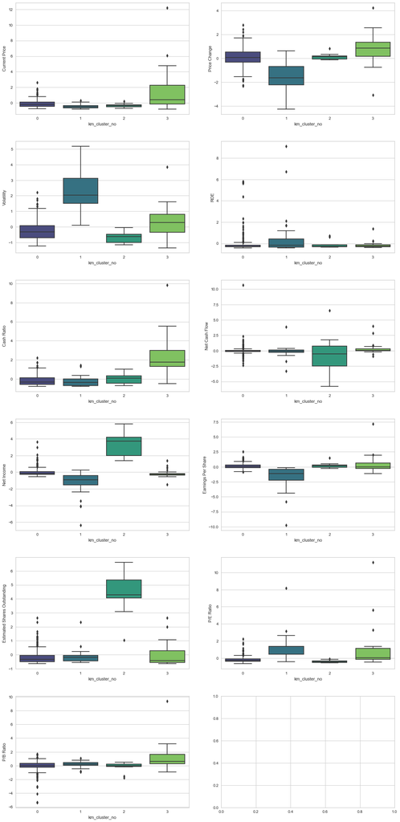

```python
# show boxplots of numerical variables for each K-Means cluster
fig, axes = plt.subplots(6, 2, figsize=(15, 30))
counter = 0

for ii in range(6):
    for jj in range(2):
        if counter < 11:
            sns.boxplot(
                ax=axes[ii][jj],
                data=df_km_scaled,
                y=df_km_scaled.columns[counter],
                x="km_cluster_no",
                palette="viridis",
            )
            counter = counter + 1

fig.tight_layout(pad=3.0)
```

## Insights

### Cluster 0

- This cluster contains 278 securities, almost 82% of the listed stocks.
- Almost all GICS sectors have majority of their listed equities in this cluster. The only exception is the Energy Sector which has majority of its securities in Cluster 1.
- These cluster is characterised by a low Estimated Shares outstanding and a negative price per book ratio.
- All other economic indicators like current price, price change per quarter, cah rato, net income, net cash flow, earnings per share, volatility, ROE and P/E ratio are all moderate. ##### **This group of securities could be classified as the moderate performers**

### Cluster 1

- This cluster contains 27 securities, 22 of which is drawn from the Energy sector. another 3 from the Information Technology sector and 1 each from the Industrials and materials sectors.
- The stocks here are characterised by negative Net income, Net cash Flow, Earnings per share, and price change per quarter.
- The stocks have high Return on Equity ROE, high Price per earnings ratio (P/E ratio) and the prices are very volatile.
- These group of shares have the lowest average current price for all the stocks listed, and their average cash ratio is also low.
- A high Volatility is high with a negative price change is an indication of rapid loss in value in an equity. ##### **The group of securities in this cluster could be classified as the lowest performers amongst the listed equities**

### Cluster 2

- This cluster contains 11 securities made up of 3 securities from the Financials sector, 2 from Health care, 2 from telecommunications services, and 1 each from Information Technology,Energy, Consumer Staples, and Consumer discretionary sectors.
- These group of equities are characterised by high Net Income and a high estimated shares outstanding.
- Negative Net cash Flow and Price per book value
- Low Volatility and P/E Ratio
- Moderate Price Change per quarter, Current price, ROE, Cash Ratio, and Earnings per share. ##### **This cluster contains securities that could be classified as low to moderate performers**

### Cluster 3

- This sector contains 24 securities made up of 9 securities from the Health care sector, 6 from Consumer discretionary, 5 from Information Technology and 1 each from Energy, Real Estate, Telecommunications Services and Consumer Staples.
- They are characterised by very high Current price, price Changeper quarter, Cash ratio, Net cash flow, Earnings per share, and price per Book value.
- the volatility is moderately high with the highest average price change amongst the listed securities over the last quarter, which is an indication of an equity whose price is continuously appreciating.
- Net Income is moderate. So also is Price per earnings ratio. The estimated shares outstanding is also moderate. ##### **This cluster contains the highest performers amongst the listed equities**

## Hierarchical Clustering

```python
# list of distance metrics
distance_metrics = ["euclidean", "chebyshev", "mahalanobis", "cityblock"]

# list of linkage methods
linkage_methods = ["single", "complete", "average", "weighted"]

high_cophenet_corr = 0
high_dm_lm = [0, 0]

for dm in distance_metrics:
    for lm in linkage_methods:
        Z = linkage(df_subset_scaled, metric=dm, method=lm)
        c, coph_dists = cophenet(Z, pdist(df_subset_scaled))
        print(
            "Cophenetic correlation for {} distance and {} linkage is {}.".format(
                dm.capitalize(), lm, c
            )
        )
        if high_cophenet_corr < c:
            high_cophenet_corr = c
            high_dm_lm[0] = dm
            high_dm_lm[1] = lm
```

```
Cophenetic correlation for Euclidean distance and single linkage is 0.9232271494002922.
Cophenetic correlation for Euclidean distance and complete linkage is 0.7873280186580672.
Cophenetic correlation for Euclidean distance and average linkage is 0.9422540609560814.
Cophenetic correlation for Euclidean distance and weighted linkage is 0.8693784298129404.
Cophenetic correlation for Chebyshev distance and single linkage is 0.9062538164750717.
Cophenetic correlation for Chebyshev distance and complete linkage is 0.598891419111242.
Cophenetic correlation for Chebyshev distance and average linkage is 0.9338265528030499.
Cophenetic correlation for Chebyshev distance and weighted linkage is 0.9127355892367.
Cophenetic correlation for Mahalanobis distance and single linkage is 0.925919553052459.
Cophenetic correlation for Mahalanobis distance and complete linkage is 0.792530720285.
Cophenetic correlation for Mahalanobis distance and average linkage is 0.9247324030159737.
Cophenetic correlation for Mahalanobis distance and weighted linkage is 0.8708317490180426.
Cophenetic correlation for Cityblock distance and single linkage is 0.9334186366528574.
Cophenetic correlation for Cityblock distance and complete linkage is 0.7375328863205818.
Cophenetic correlation for Cityblock distance and average linkage is 0.9302145048594667.
Cophenetic correlation for Cityblock distance and weighted linkage is 0.731045513520281.
```

```python
# printing the combination of distance metric and linkage method with the highest cophenetic correlation
print(
    "Highest cophenetic correlation is {}, which is obtained with {} distance and {} linkage.".format(
        high_cophenet_corr, high_dm_lm[0].capitalize(), high_dm_lm[1]
    )
)
```

```
Highest cophenetic correlation is 0.9422540609560814, which is obtained with Euclidean distance and average linkage.
```

**Let's explore different linkage methods with Euclidean distance only.**

```python
# list of linkage methods
linkage_methods = ["single", "complete", "average", "centroid", "ward", "weighted"]

high_cophenet_corr = 0
high_dm_lm = [0, 0]

for lm in linkage_methods:
    Z = linkage(df_subset_scaled, metric="euclidean", method=lm)
    c, coph_dists = cophenet(Z, pdist(df_subset_scaled))
    print("Cophenetic correlation for {} linkage is {}.".format(lm, c))
    if high_cophenet_corr < c:
        high_cophenet_corr = c
        high_dm_lm[0] = "euclidean"
        high_dm_lm[1] = lm
```

```
Cophenetic correlation for single linkage is 0.9232271494002922.
Cophenetic correlation for complete linkage is 0.7873280186580672.
Cophenetic correlation for average linkage is 0.9422540609560814.
Cophenetic correlation for centroid linkage is 0.9314012446828154.
Cophenetic correlation for ward linkage is 0.7101180299865353.
Cophenetic correlation for weighted linkage is 0.8693784298129404.
```

```python
# printing the combination of distance metric and linkage method with the highest cophenetic correlation
print(
    "Highest cophenetic correlation is {}, which is obtained with {} linkage.".format(
        high_cophenet_corr, high_dm_lm[1]
    )
)
```

```
Highest cophenetic correlation is 0.9422540609560814, which is obtained with average linkage.
```

**Observation**

### Checking Dendrograms

*Checking the dendrograms for the different linkage methods.*

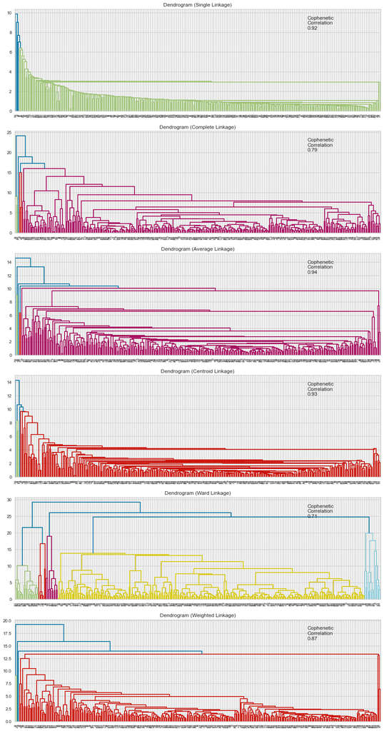

```python
# list of linkage methods
linkage_methods = ["single", "complete", "average", "centroid", "ward", "weighted"]

# lists to save results of cophenetic correlation calculation
compare_cols = ["Linkage", "Cophenetic Coefficient"]

# to create a subplot image
fig, axs = plt.subplots(len(linkage_methods), 1, figsize=(15, 30))

# We will enumerate through the list of linkage methods above
# For each linkage method, we will plot the dendrogram and calculate the cophenetic correlation
for i, method in enumerate(linkage_methods):
    Z = linkage(df_subset_scaled, metric="euclidean", method=method)

    dendrogram(Z, ax=axs[i])
    axs[i].set_title(f"Dendrogram ({method.capitalize()} Linkage)")

    coph_corr, coph_dist = cophenet(Z, pdist(df_subset_scaled))
    axs[i].annotate(
        f"Cophenetic\nCorrelation\n{coph_corr:0.2f}",
        (0.80, 0.80),
        xycoords="axes fraction",
    )
```

### Observations

- The cophenetic correlation for average linkage basing our metric on euclidian distance is the highest with a score of 0.94, but the clusters do not seem to have enough variability.
- Whereas the cophenetic correlation for ward linkage is 0.71 but the dendrogram appears to provide better clusters.
- We will try both of them and settle for the one with the better variability.
- 5 appears to be the appropriate number of clusters for both linkage methods at a dendrogram distance of 10 for average linkage, and a dendrogram distance of 20 for ward linkage.

```python
# Creating a copy of the original dataset to be used for hierachical cluster profiling
df_hc_ave = df.copy()
```

```python
# Define the hierarchical clustering model using 5 as the number of clusters chosen
HCmodel = AgglomerativeClustering(n_clusters=5, affinity="euclidean", linkage="average")
# Fit the model to the scaled dataset
HCmodel.fit(df_subset_scaled)
```

```
AgglomerativeClustering(linkage='average', n_clusters=5)
```

```python
# Adding cluster labels to the copy of the original dataset
df_hc_ave["cluster_no"] = HCmodel.labels_
```

```python
# Group dataset by cluster labels
cluster_profile = df_hc_ave.groupby("cluster_no").mean()
```

```python
# add counts for number of stocks in each cluster and display the cluster profiles
cluster_profile["count_in_each_cluster"] = (
    df_hc_ave.groupby("cluster_no")["Security"].count().values
)
cluster_profile
```

| cluster_no | Current Price | Price Change | Volatility | ROE | Cash Ratio | Net Cash Flow | Net Income | Earnings Per Share | Estimated Shares Outstanding | P/E Ratio | P/B Ratio | count_in_each_cluster |
| --- | --- | --- | --- | --- | --- | --- | --- | --- | --- | --- | --- | --- |
| 0 | 77.88 | 4.11 | 1.52 | 35.32 | 66.78 | -32,825,817.37 | 1,535,255,703.59 | 2.90 | 559,027,333.15 | 32.44 | -1.78 | 334 |
| 1 | 25.64 | 11.24 | 1.32 | 12.50 | 130.50 | 16,755,500,000.00 | 13,654,000,000.00 | 3.29 | 2,791,829,362.10 | 13.65 | 1.51 | 2 |
| 2 | 24.49 | -13.35 | 3.48 | 802.00 | 51.00 | -1,292,500,000.00 | -19,106,500,000.00 | -41.81 | 519,573,983.25 | 60.75 | 1.57 | 2 |
| 3 | 104.66 | 16.22 | 1.32 | 8.00 | 958.00 | 592,000,000.00 | 3,669,000,000.00 | 1.31 | 2,800,763,359.00 | 79.89 | 5.88 | 1 |
| 4 | 1,274.95 | 3.19 | 1.27 | 29.00 | 184.00 | -1,671,386,000.00 | 2,551,360,000.00 | 50.09 | 50,935,516.07 | 25.45 | -1.05 | 1 |

#### Observations

- There are 334 securities in one cluster, the remaining 4 clusters shared the remaining 6 securities between them with 2 clusters having 2 securies each and the remaining two clusters having 1 security each.
- We can therefore conclude that the average linkage method does not provide enough variability with the clusters formed with our dataset.
- We will therefore use the ward method for our final model

### Creating the Final Model

```python
# Creating a copy of the original dataset to be used for hierachical cluster profiling
df_hc_ward = df.copy()
```

```python
# Define the hierarchical clustering model using 5 as the number of clusters chosen
HCmodel = AgglomerativeClustering(n_clusters=5, affinity="euclidean", linkage="ward")
# Fit the model to the scaled dataset
HCmodel.fit(df_subset_scaled)
```

```
AgglomerativeClustering(n_clusters=5)
```

```python
# Adding cluster labels to the copy of the original dataset
df_hc_ward["hc_cluster_no"] = HCmodel.labels_
```

```python
# Adding cluster labels to the scaled dataset (for plotting the final boxplots)
df_hc_scaled = df_subset_scaled.copy()
df_hc_scaled["hc_cluster_no"] = HCmodel.labels_
```

```python
# Group dataset by cluster labels
cluster_profile = df_hc_ward.groupby("hc_cluster_no").mean()
```

```python
# add counts for number of stocks in each cluster and display the cluster profiles
cluster_profile["count_in_each_cluster"] = (
    df_hc_ward.groupby("hc_cluster_no")["Security"].count().values
)
cluster_profile.style.highlight_max(color="lime", axis=0).highlight_min(
    color="yellow", axis=0
).highlight_between(left=-9000000000, right=0, color="deeppink", axis=0)
```

| hc_cluster_no | Current Price | Price Change | Volatility | ROE | Cash Ratio | Net Cash Flow | Net Income | Earnings Per Share | Estimated Shares Outstanding | P/E Ratio | P/B Ratio | count_in_each_cluster |
| --- | --- | --- | --- | --- | --- | --- | --- | --- | --- | --- | --- | --- |
| 0 | 326.198218 | 10.563242 | 1.642560 | 14.400000 | 309.466667 | 288850666.666667 | 864498533.333333 | 7.785333 | 544900261.301333 | 113.095334 | 19.142151 | 15 |
| 1 | 84.355716 | 3.854981 | 1.827670 | 633.571429 | 33.571429 | -568400000.000000 | -4968157142.857142 | -10.841429 | 398169036.442857 | 42.284541 | -11.589502 | 7 |
| 2 | 42.848182 | 6.270446 | 1.123547 | 22.727273 | 71.454545 | 558636363.636364 | 14631272727.272728 | 3.410000 | 4242572567.290909 | 15.242169 | -4.924615 | 11 |
| 3 | 72.760400 | 5.213307 | 1.427078 | 25.603509 | 60.392982 | 79951512.280702 | 1538594322.807018 | 3.655351 | 446472132.228456 | 24.722670 | -2.647194 | 285 |
| 4 | 36.440455 | -16.073408 | 2.832884 | 57.500000 | 42.409091 | -472834090.909091 | -3161045227.272727 | -8.005000 | 514367806.201818 | 85.555682 | 0.836839 | 22 |

#### Highlight colors:

- Max - Green
- Min - Yellow
- Negative - Pink

```python
# print the names of the companies in each cluster
for num in df_hc_ward["hc_cluster_no"].unique():
    print("In cluster {}, the following companies are present:".format(num))
    print(df_hc_ward[df_hc_ward["hc_cluster_no"] == num]["Security"].unique().tolist())
    print("=" * 120, "\n")
```

```
In cluster 3, the following companies are present:
['American Airlines Group', 'AbbVie', 'Abbott Laboratories', 'Adobe Systems Inc', 'Analog Devices, Inc.', 'Archer-Daniels-Midland Co', 'Ameren Corp', 'American Electric Power', 'AFLAC Inc', 'American International Group, Inc.', 'Apartment Investment & Mgmt', 'Assurant Inc', 'Arthur J. Gallagher & Co…
========================================================================================================================

In cluster 0, the following companies are present:
['Alliance Data Systems', 'Alexion Pharmaceuticals', 'Amgen Inc', 'Amazon.com Inc', 'Chipotle Mexican Grill', 'Equinix', 'Facebook', 'Frontier Communications', 'Intuitive Surgical Inc.', 'Monster Beverage', 'Netflix Inc.', 'Priceline.com Inc', 'Regeneron', 'Waters Corporation', 'Yahoo Inc.']
========================================================================================================================

In cluster 1, the following companies are present:
['Allegion', 'Apache Corporation', 'Chesapeake Energy', 'Charter Communications', 'Colgate-Palmolive', 'Kimberly-Clark', 'S&P Global, Inc.']
========================================================================================================================

In cluster 4, the following companies are present:
['Anadarko Petroleum Corp', 'Baker Hughes Inc', 'Cabot Oil & Gas', 'Concho Resources', 'Devon Energy Corp.', 'EOG Resources', 'Freeport-McMoran Cp & Gld', 'Hess Corporation', 'Kinder Morgan', 'Marathon Oil Corp.', 'Murphy Oil', 'Noble Energy Inc', 'Newfield Exploration Co', 'National Oilwell Varco I…
========================================================================================================================

In cluster 2, the following companies are present:
['Bank of America Corp', 'Citigroup Inc.', 'Ford Motor', 'Intel Corp.', 'JPMorgan Chase & Co.', 'Coca Cola Company', 'Pfizer Inc.', 'AT&T Inc', 'Verizon Communications', 'Wells Fargo', 'Exxon Mobil Corp.']
========================================================================================================================
```

```python
# print number of stocks within each sector for all of the clusters
for k in range(0, df_hc_ward["hc_cluster_no"].nunique()):
    print(
        "The number of stocks within each GICS Sector for Cluster " + str(k) + " are:"
    )
    print(df_hc_ward[df_hc_ward["hc_cluster_no"] == k]["GICS Sector"].value_counts())
    print("=" * 120, "\n")
```

```
The number of stocks within each GICS Sector for Cluster 0 are:
Health Care                    5
Information Technology         4
Consumer Discretionary         3
Real Estate                    1
Telecommunications Services    1
Consumer Staples               1
Name: GICS Sector, dtype: int64
========================================================================================================================

The number of stocks within each GICS Sector for Cluster 1 are:
Energy                    2
Consumer Staples          2
Industrials               1
Consumer Discretionary    1
Financials                1
Name: GICS Sector, dtype: int64
========================================================================================================================

The number of stocks within each GICS Sector for Cluster 2 are:
Financials                     4
Telecommunications Services    2
Consumer Discretionary         1
Information Technology         1
Consumer Staples               1
Health Care                    1
Energy                         1
Name: GICS Sector, dtype: int64
========================================================================================================================

The number of stocks within each GICS Sector for Cluster 3 are:
Industrials                    52
Financials                     44
Consumer Discretionary         35
Health Care                    34
Information Technology         27
Real Estate                    26
Utilities                      24
Materials                      19
Consumer Staples               15
Energy                          7
Telecommunications Services     2
Name: GICS Sector, dtype: int64
========================================================================================================================

The number of stocks within each GICS Sector for Cluster 4 are:
Energy                    20
Materials                  1
Information Technology     1
Name: GICS Sector, dtype: int64
========================================================================================================================
```

```python
# GICS Sector type representation in each cluster
pd.crosstab(df_hc_ward["hc_cluster_no"], df_hc_ward["GICS Sector"]).style.highlight_max(
    color="lime", axis=1
)
```

| GICS Sector hc_cluster_no | Consumer Discretionary | Consumer Staples | Energy | Financials | Health Care | Industrials | Information Technology | Materials | Real Estate | Telecommunications Services | Utilities |
| --- | --- | --- | --- | --- | --- | --- | --- | --- | --- | --- | --- |
| 0 | 3 | 1 | 0 | 0 | 5 | 0 | 4 | 0 | 1 | 1 | 0 |
| 1 | 1 | 2 | 2 | 1 | 0 | 1 | 0 | 0 | 0 | 0 | 0 |
| 2 | 1 | 1 | 1 | 4 | 1 | 0 | 1 | 0 | 0 | 2 | 0 |
| 3 | 35 | 15 | 7 | 44 | 34 | 52 | 27 | 19 | 26 | 2 | 24 |
| 4 | 0 | 0 | 20 | 0 | 0 | 0 | 1 | 1 | 0 | 0 | 0 |

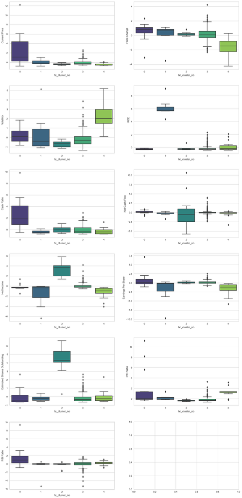

```python
# show boxplots of numerical variables for each cluster
fig, axes = plt.subplots(6, 2, figsize=(15, 30))
counter = 0

for ii in range(6):
    for jj in range(2):
        if counter < 11:
            sns.boxplot(
                ax=axes[ii][jj],
                data=df_hc_scaled,
                y=df_hc_scaled.columns[counter],
                x="hc_cluster_no",
                palette="viridis",
            )
            counter = counter + 1

fig.tight_layout(pad=3.0)
```

## Insights

### Cluster 0

- This Cluster contains 15 securities made up of 5 securities from the Health care sector, 4 from Information Technology, 3 from Consumer discretionary, and 1 each from Real Estate, Telecommunications Services and Consumer Staples.
- These equities are characterised by very high Current prices, High price Change, Cash ratio, Earnings per share, Price per earnings ratio and price per Book value.
- the volatility is moderately high. This with the high average price change amongst the listed securities in the last quarter indicates an equity whose price is continuously appreciating.
- Other economic indicators such as Net income, Net cash Flow and Estimated outstanding shares are moderate. ##### **This cluster contains the highest performers amongst the listed equities**

### Cluster 1

- This cluster contains 7 securities made up of 2 securities from the Energy sector, 2 from Consumer staples, and 1 each from Consumer discretionary, Financials and Industrials.
- The stocks here are characterised by negative Net income, Net cash Flow, Earnings per share, and Price per book ratio.
- These equities have a low cash rtio and Estimated Outstanding Shares, but they have a high ROE.
- The volatility is moderate. So also are the Current price, average price change per quarter, and Price per Earnings ratio. ##### **This cluster contains low performing securities**

### Cluster 3

- This cluster contains 285 securities, almost 84% of the listed stocks.
- Almost all GICS sectors have majority of their listed equities in this cluster. The only exception is the Energy Sector which has majority of its securities in Cluster 4.
- These cluster is characterised by mostly moderate economic indicators except for the Price per book ratio, which is negative.. ##### **This group of securities could be classified as the moderate performers**

## K-means vs Hierarchical Clustering

```python
pd.crosstab(df_kmeans.km_cluster_no, df_hc_ward.hc_cluster_no).style.highlight_max(
    color="lime", axis=1
)
```

| hc_cluster_no km_cluster_no | 0 | 1 | 2 | 3 | 4 |
| --- | --- | --- | --- | --- | --- |
| 0 | 0 | 5 | 1 | 271 | 1 |
| 1 | 1 | 2 | 0 | 3 | 21 |
| 2 | 0 | 0 | 10 | 1 | 0 |
| 3 | 14 | 0 | 0 | 10 | 0 |

### Insights

**Which clustering technique took less time for execution?**

- The execution time for both clustering methods is very similar. We know for certain that this is due to the number of observations (340) we are working with. As the number of observations increase, the K-Means clustering method is going to offer a better performance in terms of execution speed over the Agglometrative clustering technique.

**Which clustering technique gave you more distinct clusters, or are they the same?**

- The hierachichal clustering method gave a clearer picture of how many clusters we should use just by looking at the dendrogram created by the model.

**How many clusters are obtained as the appropriate number of clusters from both algorithms?**

- Looking at the dendrograms created by the agglomerative clustering technique, we were able to identify 5 custers at a dendogram distance of 20, whereas we use the KElbowVisualizer and the SilhouetteVisualizer to subjectively arrive at an optimal cluster number for the K-Means clustering technique.

## Actionable Insights and Recommendations

- The listed securities have been separated into 4 clusters (we shall treat Clusters 1 & 4 of the hierachical clustering method as 1 for the purpose of alignment with the Kmeans clustering method).The four clusters has been identified as:
- The high performers
- The moderate performers
- The low to moderate performers
- The low performers
- An investor, based on their appetite for risk and after due consideration of the interplay between some of the economic indicators could choose which of the clusters to concentrate on in the bid to maximise their earnings in any market condition.
- Trade & Ahead should also continue with dynamic clustering. This becomes necessary as there is a propensity for securities to move accross clusters as more more equities are added into the mix, coupled with the fact that market conditions and therefore economic indicators are bound to change from time to time. Doing dynamic clustering will improve the accuracy of Trade & Ahead's predictions and therefore their Sell/buy recommendations to their clients.